# Stat 115 Lab 3

Batch Effect, Clustering, PCA, Odyssey

Andy Shi

February 12-14, 2018

## Announcements

- HW2 out, due 2/24 at 11:59pm.
- Please fill out the survey for HW1 on Canvas, under quizzes.

## Outline

- LIMMA with contrasts.
- Batch effect:
  - Can detect batch effect with clustering.
  - Correct with ComBat.
- PCA.
- Kmeans.
- Odyssey:
  - Logging in, moving around.
  - Managing files.
  - Basic bash commands.
  - Slurm scripts.
  - BWA.
  - STAR.
- Next week: KNN, SVM, Cross-validation, DAVID, GSEA.

## Install and Load Packages

```r
# install packages from bioconductor
if (!requireNamespace("BiocManager", quietly = TRUE))
    install.packages("BiocManager")
BiocManager::install("bladderbatch", version = "3.8")
BiocManager::install("leukemiasEset", version = "3.8")
```

```r
library(sva)
library(limma)
library(bladderbatch)
library(leukemiasEset)
library(dplyr)
library(biobroom)
library(ggplot2)
```

## LIMMA with Contrasts

- Several different groups to compare, but want to pool data to estimate variances.
- Will want to consider this for the Taylor data in Part II.
- For Part I, can either analyze the two cell lines separately or also use a contrast.

## Load Example Data

```r
data(leukemiasEset)
table(leukemiasEset$LeukemiaType)
```

```
##
## ALL AML CLL CML NoL
##  12  12  12  12  12
```

```r
# subset to ALL, AML, and NoL
ind <- leukemiasEset$LeukemiaType %in% c("ALL", "AML", "NoL")
ourData <- leukemiasEset[, leukemiasEset$LeukemiaType %in% c("ALL", "AML", "NoL")]
LeukemiaType <- factor(ourData$LeukemiaType)
leukemia_expr <- exprs(ourData)
```

## Limma Design Matrix

- Design Matrix has 3 columns: ALL, AML, and NoL.
- `makeContrasts` function tells limma what comparisons we want to make.

```r
design <- model.matrix(~0 + LeukemiaType)
head(design, 5)
```

```
##   LeukemiaTypeALL LeukemiaTypeAML LeukemiaTypeNoL
## 1               1               0               0
## 2               1               0               0
## 3               1               0               0
## 4               1               0               0
## 5               1               0               0
```

```r
colnames(design) <- c("ALL", "AML", "NoL") # rename columns
head(design, 5)
```

```
##   ALL AML NoL
## 1   1   0   0
## 2   1   0   0
## 3   1   0   0
## 4   1   0   0
## 5   1   0   0
```

```r
contrasts.mat <- makeContrasts(ALLvsNoL = ALL - NoL,
                               AMLvsNoL = AML - NoL,
                               ALLvsAML = ALL - AML,
                               levels = design)
```

## Limma Fitting

- Basically like before, except we add the `contrast.fit`.
- To calculate FDR, first group by the comparison (`term` column).
- Can then filter by term, fdr, log2-fold change (estimate)

```r
limma_fit <- lmFit(leukemia_expr, design) %>%
    contrasts.fit(contrasts.mat) %>%
    eBayes() %>%
    tidy()
limma_fit
```

```
## # A tibble: 60,516 x 6
##    gene            term     estimate statistic  p.value    lod
##    <chr>           <fct>       <dbl>     <dbl>    <dbl>  <dbl>
##  1 ENSG00000000003 ALLvsNoL  -0.263    -3.31   2.14e- 3  -1.97
##  2 ENSG00000000005 ALLvsNoL  -0.0465   -0.579  5.66e- 1  -6.64
##  3 ENSG00000000419 ALLvsNoL  -0.0821   -0.385  7.02e- 1  -6.74
##  4 ENSG00000000457 ALLvsNoL   0.0159    0.0676 9.46e- 1  -6.81
##  5 ENSG00000000460 ALLvsNoL  -0.384    -1.51   1.40e- 1  -5.69
##  6 ENSG00000000938 ALLvsNoL  -4.15     -8.20   1.09e- 9  12.1
##  7 ENSG00000000971 ALLvsNoL  -0.169    -0.498  6.22e- 1  -6.69
##  8 ENSG00000001036 ALLvsNoL  -3.18     -8.55   4.03e-10  13.1
##  9 ENSG00000001084 ALLvsNoL  -2.14     -7.92   2.41e- 9  11.4
## 10 ENSG00000001167 ALLvsNoL   0.511     2.64   1.24e- 2  -3.59
## # ... with 60,506 more rows
```

```r
limma_fit <- limma_fit %>% group_by(term) %>%
    mutate(fdr = p.adjust(p.value, method = "fdr")) %>%
    ungroup()
limma_fit %>% filter(term == "ALLvsNoL") %>% arrange(p.value)
```

```
## # A tibble: 20,172 x 7
##    gene            term     estimate statistic  p.value   lod      fdr
##    <chr>           <fct>       <dbl>     <dbl>    <dbl> <dbl>    <dbl>
##  1 ENSG00000173391 ALLvsNoL    -4.28     -20.1 6.87e-21  36.6 1.38e-16
##  2 ENSG00000228278 ALLvsNoL    -3.26     -16.7 2.59e-18  31.2 2.62e-14
##  3 ENSG00000102935 ALLvsNoL     4.99      15.7 1.59e-17  29.5 1.07e-13
##  4 ENSG00000119862 ALLvsNoL    -2.76     -15.5 2.42e-17  29.1 1.22e-13
##  5 ENSG00000164330 ALLvsNoL     4.91      15.4 3.26e-17  28.8 1.31e-13
##  6 ENSG00000229314 ALLvsNoL    -5.06     -14.9 8.03e-17  28.0 2.56e-13
##  7 ENSG00000133063 ALLvsNoL    -4.29     -14.9 8.90e-17  27.9 2.56e-13
##  8 ENSG00000145569 ALLvsNoL    -2.85     -14.6 1.56e-16  27.4 3.93e-13
##  9 ENSG00000100099 ALLvsNoL     2.47      14.3 2.96e-16  26.8 6.64e-13
## 10 ENSG00000162444 ALLvsNoL    -3.85     -14.2 3.93e-16  26.5 7.93e-13
## # ... with 20,162 more rows
```

## KMeans

- An unsupervised method to cluster the data (no labels/outcomes provided).
- Requires that you specify the number of clusters in advance.
- We can use either all the genes, or only the differentally expressed genes.
- We can subset the `leukemia_expr` matrix using the row names.

```r
genelist <- limma_fit %>%
    filter(fdr <= 0.05, abs(estimate) >= log2(1.5)) %>%
    distinct(gene)
leukemia_subset <- leukemia_expr[genelist$gene, ]
```

## KMeans: Running

- KMeans algorithm is random and does not always find the global optimum.
  - Can try random restarts (`nstarts` option) to get a better solution.
- Can visualize results in a table.
- Remember the cluster labels (1, 2, 3) are arbitrary and can change from run to run.

```r
leukemia_km1 <- kmeans(t(leukemia_subset), centers = 3, nstart = 10)
data.frame(type = ourData$LeukemiaType,
           cluster = leukemia_km1$cluster) %>%
    table()
```

```
##      cluster
## type   1  2  3
##   ALL  0  0 12
##   AML 10  2  0
##   CLL  0  0  0
##   CML  0  0  0
##   NoL  0 12  0
```

```r
leukemia_km2 <- kmeans(t(leukemia_expr), centers = 3, nstart = 10)
data.frame(type = ourData$LeukemiaType,
           cluster = leukemia_km2$cluster) %>%
    table()
```

```
##      cluster
## type   1  2  3
##   ALL  2  0 10
##   AML  7  3  2
##   CLL  0  0  0
##   CML  0  0  0
##   NoL  0 12  0
```

## Break

## Batch Effect

- Why is batch effect a problem?
- Example data: Gene expression data from investigation into bladder cancer.
- Outcome: finding differentially expressed genes that are associated with cancer status (0/1 in the variable `hasCancer`).
- Already normalized with RMA.
- `pheno`: Dataset that contains phenotypes.
- `edata`: Expression matrix.

```r
data(bladderdata)
pheno <- pData(bladderEset)
pheno <- pheno %>%
    mutate(hasCancer = as.numeric(cancer == "Cancer"))
head(pheno)
```

```
##   sample outcome batch cancer hasCancer
## 1      1  Normal     3 Normal         0
## 2      2  Normal     2 Normal         0
## 3      3  Normal     2 Normal         0
## 4      4  Normal     3 Normal         0
## 5      5  Normal     3 Normal         0
## 6      6  Normal     3 Normal         0
```

```r
edata <- exprs(bladderEset)
```

## Hierarchical Clustering

- A way to visualize batch effect.
- Can be used to cluster many types of data.
- Don’t need to pre-specify the number of clusters.
- Use the `hclust` command.
- Can plot the clustering result with `plot`.
- Clustering requires distances between each of the samples.
- Can have different types of linkages: if we know the distance between samples, how to calculate the distance between two clusters?
  - Recall, at each step we join the two closest clusters.

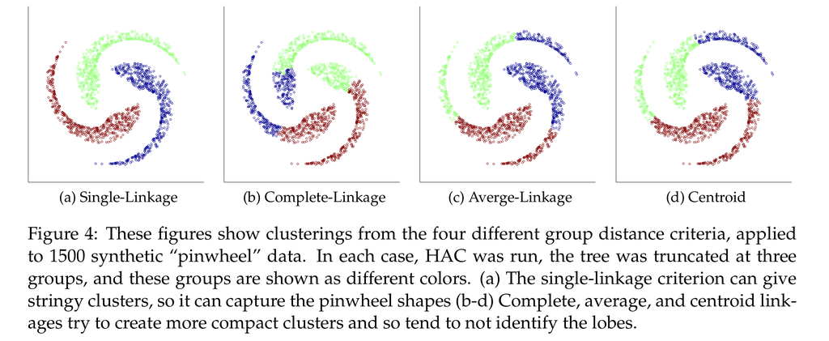

Source: CS 181 course notes by Ryan Adams.

## Clustering Code

- Question: Why do I need `t` in the code below?
- Linkage specified using the `method` argument.

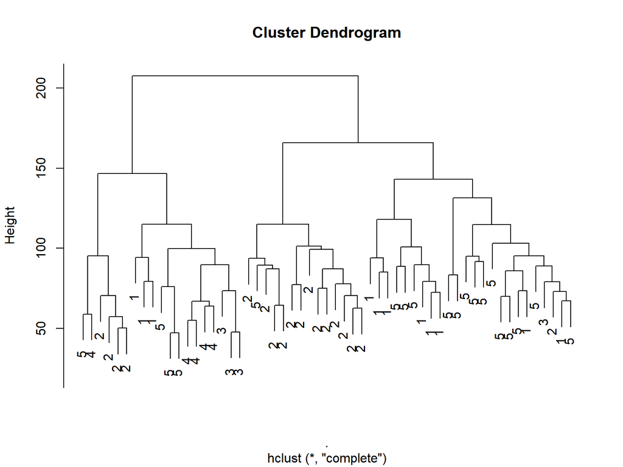

```r
clustering <- edata %>% t() %>% dist() %>%
    hclust(method = "complete")
plot(clustering, labels = pheno$batch)
```

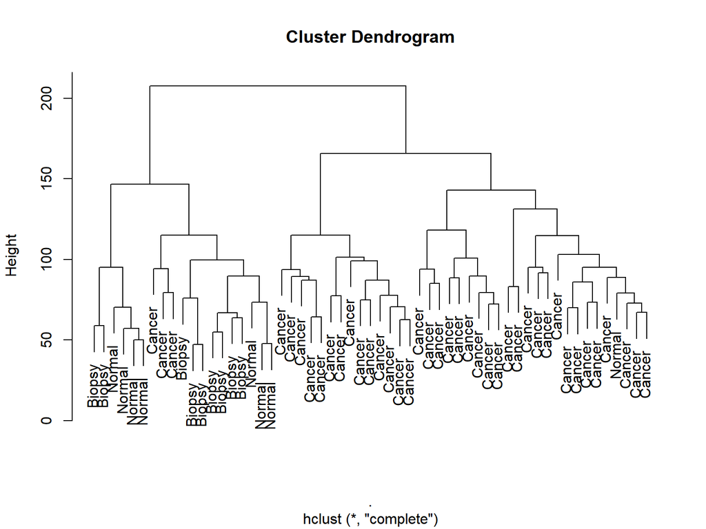

```r
plot(clustering, labels = pheno$cancer)
```

## ComBat

- Perform batch effect adjustment
- Need to specify model matrix: same matrix you use for LIMMA
- Tells ComBat to remove the batch effect but not to remove the association due to whatever model you are going to run.
- In this example, we model gene expression as a function of whether or not the sample is cancerous (`hasCancer` variable)

```r
model <- model.matrix(~pheno$hasCancer)
combat_edata <- ComBat(dat = edata, batch = pheno$batch, mod = model)
```

```
## Found5batches
```

```
## Adjusting for1covariate(s) or covariate level(s)
```

```
## Standardizing Data across genes
```

```
## Fitting L/S model and finding priors
```

```
## Finding parametric adjustments
```

```
## Adjusting the Data
```

## Check Clustering Again

- Can you perform clustering to check whether ComBat removed the batch effect?

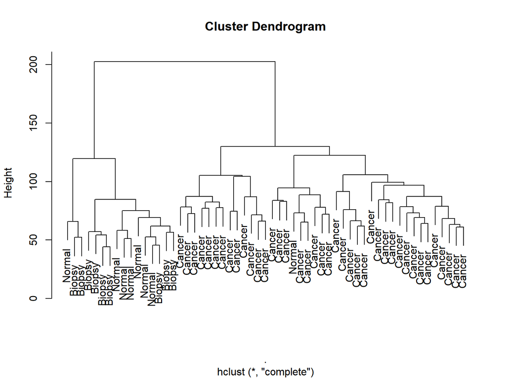

```r
clustering_combat <- combat_edata %>% t() %>% dist() %>%
    hclust(method = "complete")
plot(clustering_combat, labels = pheno$cancer)
```

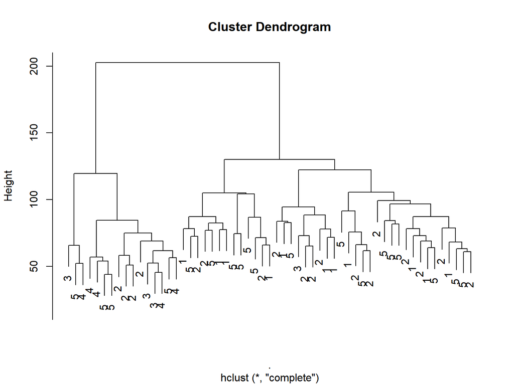

```r
plot(clustering_combat, labels = pheno$batch)
```

## Break

## PCA

- Finds the best linear combinations of the variables.
- “Best” means optimally describing the variance.
- Can produce lower-dimensional summaries of the data.
  - Take 100 numbers per sample and summarize them with 2 numbers per sample.
- Useful for visualization, among other things.

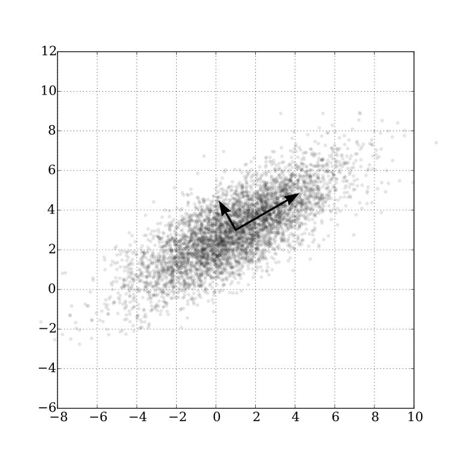

Source: https://en.wikipedia.org/wiki/File:GaussianScatterPCA.svg

## PCA

- Main function: `prcomp`.
- Want to center and scale your data. For example, if you were doing PCA for car data, two variables could be number of cylinders and weight of the car.
- Cars might have 4-8 cylinders, but weight could be measured in kilograms or grams.
- Don’t want weight to have higher influence just because of how it’s measured.

## PCA Code

```r
pca_result <- edata %>% t() %>% prcomp(center = TRUE, scale. = TRUE)
edata_pc_df <- as.data.frame(pca_result$x)
edata_pc_df <- edata_pc_df %>%
    mutate(batch = as.factor(pheno$batch),
           hasCancer = as.factor(pheno$hasCancer))
edata_pc_df[1:5, 1:5]
```

```
##          PC1         PC2        PC3       PC4         PC5
## 1  -51.96406   0.2653562  -2.563985  7.075911 -22.6585436
## 2 -182.23077  -4.9811639  12.521706  5.759610  22.5250017
## 3 -184.03994 -23.6082592   5.339415 13.985473  20.7739442
## 4 -116.19732  33.1625079 -15.348761  9.924097  -0.8045753
## 5  -39.90127  29.8352519 -17.538833  7.890477 -19.1428102
```

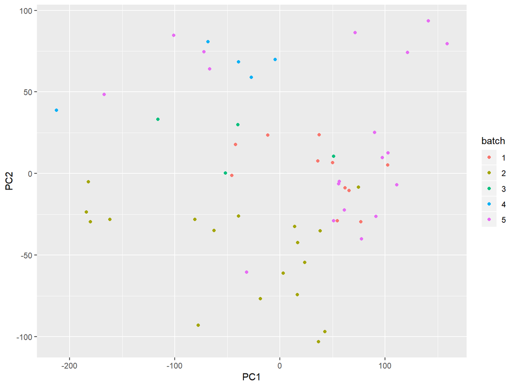

```r
ggplot(edata_pc_df, aes(x = PC1, y = PC2, color = batch)) +
    geom_point()
```

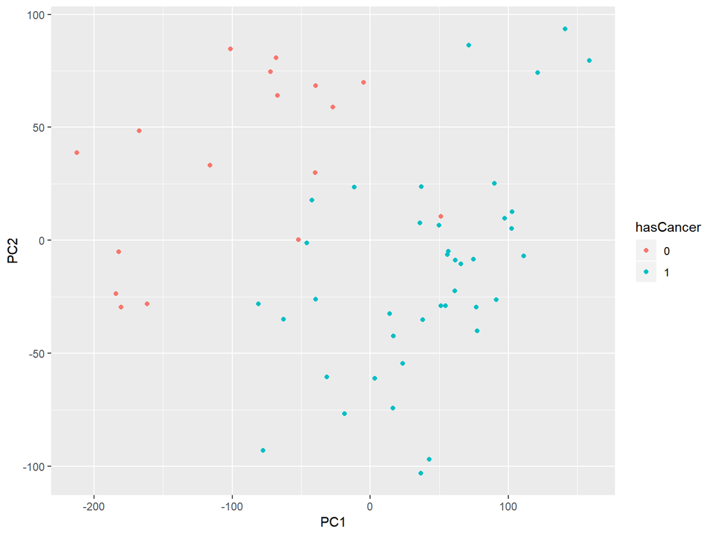

```r
ggplot(edata_pc_df, aes(x = PC1, y = PC2, color = hasCancer)) +
    geom_point()
```

## R Aside: Lists

- `pca_result` is a list. It holds a mix of data types.
- Can access an individual list element with `$`, e.g. `pca_result$x`.
- A lot of R functions use lists to return multiple things.
- Look at `prcomp` documentation (`?prcomp`) under Value to see the meaning of each of the things in the list.

## PCA Variance Explained

- Linear algebra result: $\text{trace}(\Sigma) = \sum_i \lambda_i$
- $\text{trace}(\Sigma)$ can be thought of as total variance.
- Variance of $PC_i$ is $\lambda_i$
- So variance explained by PCs 1 to j is $\frac{\sum_{i = 1}^j \lambda_i}{\sum_{i = 1}^K \lambda_i}$
- Denominator is sum of all eigenvalues

## PCA Variance Explained Code

- Eigenvalues are the square of `sdev`.
- Can use `which` and `min` to find how many PCs you need to explain x% of the variance.

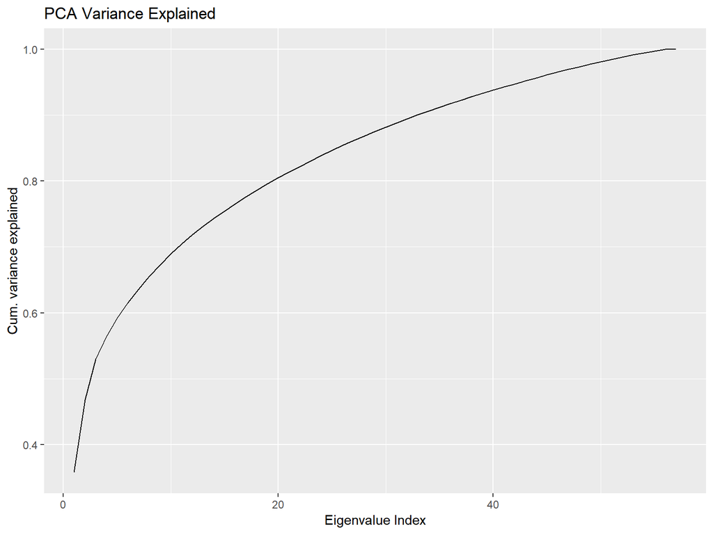

```r
eigenvals <- (pca_result$sdev)^2
n_eigenvals <- length(eigenvals)
var_explained <- cumsum(eigenvals) / sum(eigenvals)
data.frame(index = 1:n_eigenvals,
           var_explained = var_explained) %>%
    ggplot(aes(x = index, y = var_explained)) + geom_line() +
    xlab("Eigenvalue Index") + ylab("Cum. variance explained") +
    ggtitle("PCA Variance Explained")
```

```r
which(var_explained > 0.8)
```

```
##  [1] 20 21 22 23 24 25 26 27 28 29 30 31 32 33 34 35 36 37 38 39 40 41 42
## [24] 43 44 45 46 47 48 49 50 51 52 53 54 55 56 57
```

```r
min(which(var_explained > 0.8))
```

```
## [1] 20
```

## PCA After ComBat: Does it change?

- Exercise.

```r
# your turn
# run PCA on the data from ComBat, draw a plot of the result
```

## Break

## BWA

- Uses Burrows-Wheeler transform.
- Requires an index to be made before aligning.
- 3 different versions:
  - BWA-backtrack (`aln/samse/sampe`)
  - BWA-SW (`bwasw`)
  - BWA-MEM (`mem`)
- Different recommendations depending on data:
  - BWA-backtrack: Illumina reads up to 100bp
  - BWA-SW / BWA-MEM: longer sequeces from 70bp to 1Mbp
  - BWA-MEM latest version, recommended since generally faster and more accurate
  - BWA-MEM better than BWA-backtrack for 70-100bp Illumina reads
- We have short reads, so for the HW, we recommend `bwa aln`.
- How to run (basic):
  - Replace `ref.fasta` and `read1.fastq` with the path on Odyssey.

```bash
# align each end separately
bwa aln ref.fasta read1.fastq > read1.sai
bwa aln ref.fasta read2.fastq > read2.sai
# stick everything in a SAM file
bwa sampe ref.fasta read1.sai read2.sai read1.fastq read2.fastq > aln-pe.sam
# count number of aligned reads, etc.
samtools flagstat aln-pe.sam
```

## STAR

- [Star: ultrafast universal RNA-seq aligner](https://academic.oup.com/bioinformatics/article/29/1/15/272537)
  - Suffix array (SA) approach to leverage speed of binary searching.
  - Requires an index (the SA) to be created prior to aligning.
- Splice-aware aligner.
- Replace STARIndex with path of STARIndex.
- Replace read1.fastq and read2.fastq with path to the reads.
- Replace `output` with something more meaningful.

```bash
STAR --genomeDir STARIndex \
--readFilesIn read1.fastq read2.fastq \
--runThreadN 1 --outFileNamePrefix output
```

## Odyssey

- What is Odyssey? Lots of computers stringed together
- Advantage: More storage, can run many things in parallel (e.g. use 10 computers to process 10 samples at a time)
- Disadvantage: a lot of overhead to get things to work (have to make sure your stuff doesn’t interfere with other people’s stuff)
- Can’t just run stuff through the terminal on Odyssey.
- Have to submit job using srun or sbatch (preferred)
- My tip: start off by requesting very few resources and doing a test run on a small file.
- **START EARLY**. You might have to wait a long time for your jobs to run.
- Odyssey might also be slow if everyone in the class tries at the last minute.

## Odyssey Logistics

- Login using ssh (Mac/Linux) or PuTTY (Windows)
- Need both your password and 6-digit code, either on your phone or as a Java applet on your computer (I recommend going with phone).
- Transfer files using Filezilla or WinSCP.
- Details: https://www.rc.fas.harvard.edu/resources/odyssey-quickstart-guide/

## Basic Bash Commands

- `pwd`: Print Working Directory. Where am I?
- `cd folder`: Change directories.
- `cd`: Shortcut to go back to home directory.
- `..`: Shortcut for going up a directory.
  - `cd ..`
  - `cd ../../`
  - `cd ../folder`
- `~`: shortcut for home directory. Can use it like so: `cd ~/stat115-hw2`.
- `mkdir folder`: Make a directory called `folder`.
- `less file`: View a file. Press `q` to quit.
- `man cmd`: Get help on `cmd`. Press `q` to quit.
- Videos about command line: https://www.youtube.com/watch?v=U3iNcBtycaQ

## Odyssey Commands

- `sbatch submissionScript.sh`: Submit a job.
- `sacct` or `squeue`: See how my submissions are doing.
- `scancel`: Cancel a job.
- Can check job status online, too: https://portal.rc.fas.harvard.edu/login/?next=/jobs/

## Example Submission Script

- Save this to a file in your home directory (e.g. `submit.sh`).
  - Good idea to make a `stat115-hw2` folder
- Submit by running `sbatch submit.sh`.
- Can edit on your own computer using a a plain text editor (e.g. Sublime or TextEdit)
- Transfer the file using Filezilla/WinSCP.

```bash
#!/bin/bash
#SBATCH -n 1 # Number of cores requested
#SBATCH -N 1 # Ensure that all cores are on one machine
#SBATCH -t 15 # Runtime in minutes
#SBATCH -p serial_requeue # Partition to submit to
#SBATCH --mem=1G # Memory in GB (see also --mem-per-cpu)
#SBATCH -o output_%j.out # Standard out goes to this file
#SBATCH -e error_%j.err # Standard err goes to this file

# LOAD_MODULES
module load ...

# YOUR_COMMANDS_HERE
bwa aln ...
```

## Submission Script Recommended Parameters

- Runtime: 30 min for BWA, 20 min for STAR
- Memory: 5G for BWA, 32G for STAR
- Change the name of the `.out` and `.err` files to something more meaningful.
- Stick with `serial_requeue`. You’ll have to wait less.
- Need to load modules for the tools we want to use.
- Modules for BWA:

  ```
  module load bwa/0.7.15-fasrc02
  module load samtools/1.5-fasrc02
  ```

- Modules for STAR:

  ```
  module load STAR/2.6.0c-fasrc01
  ```

- Module search: https://portal.rc.fas.harvard.edu/apps/modules